# Practical machine learning. Course project

Socorro Román Moro

9/26/2021

## Background

Using devices such as Jawbone Up, Nike FuelBand, and Fitbit it is now possible to collect a large amount of data about personal activity relatively inexpensively. These type of devices are part of the quantified self movement – a group of enthusiasts who take measurements about themselves regularly to improve their health, to find patterns in their behavior, or because they are tech geeks. One thing that people regularly do is quantify how much of a particular activity they do, but they rarely quantify how well they do it. In this project, we will use data from accelerometers on the belt, forearm, arm, and dumbell of 6 participants.

## Data source

The training data for this project are available here:

https://d396qusza40orc.cloudfront.net/predmachlearn/pml-training.csv

The test data are available here:

https://d396qusza40orc.cloudfront.net/predmachlearn/pml-testing.csv

### Libraries

Load the required libraries.

```r
library(caret)
library(rpart)
library(rpart.plot)
library(rattle)
library(randomForest)
library(RColorBrewer)
```

### Data processing

Load the datasets

```r
base.training <- read.csv("pml-training.csv", na.strings=c("NA","#DIV/0!", ""))
base.testing <- read.csv("pml-testing.csv", na.strings=c("NA","#DIV/0!", ""))
```

Clean and subset the datasets

```r
base.training<-base.training[,colSums(is.na(base.training)) == 0]
base.testing <-base.testing[,colSums(is.na(base.testing)) == 0]

# remove the columns are not important to the project
base.training   <- base.training[,-c(1:7)]
base.testing <- base.testing[,-c(1:7)]

allNames <- names(base.training)
base.testing <- base.testing[,allNames[1:52]]
```

### Data partitioning

Divide the training data in training set and testing or cross validation set for prediction models.

```r
inTrain <- createDataPartition(base.training$classe, p=0.75, list = FALSE)
training.2 <- base.training[inTrain,]
cross.val <- base.training[-inTrain,]
```

### Decision tree model

```r
# fit model
dt.modifit <- train(classe ~ ., data = training.2, method="rpart")
# prediction
dt.prediction <- predict(dt.modifit, cross.val)
## change the type of the column as factor
confusionMatrix(as.factor(cross.val$classe), dt.prediction)
```

```
## Confusion Matrix and Statistics
##
##           Reference
## Prediction    A    B    C    D    E
##          A 1277   23   93    0    2
##          B  401  305  243    0    0
##          C  389   20  446    0    0
##          D  357  145  302    0    0
##          E  134  115  238    0  414
##
## Overall Statistics
##
##                Accuracy : 0.498
##                  95% CI : (0.4839, 0.5121)
##     No Information Rate : 0.5216
##     P-Value [Acc > NIR] : 0.9996
##
##                   Kappa : 0.3438
##
##  Mcnemar's Test P-Value : NA
##
## Statistics by Class:
##
##                      Class: A Class: B Class: C Class: D Class: E
## Sensitivity            0.4992  0.50164  0.33737       NA  0.99519
## Specificity            0.9497  0.85009  0.88582   0.8361  0.89149
## Pos Pred Value         0.9154  0.32139  0.52164       NA  0.45949
## Neg Pred Value         0.6349  0.92339  0.78365       NA  0.99950
## Prevalence             0.5216  0.12398  0.26958   0.0000  0.08483
## Detection Rate         0.2604  0.06219  0.09095   0.0000  0.08442
## Detection Prevalence   0.2845  0.19352  0.17435   0.1639  0.18373
## Balanced Accuracy      0.7245  0.67587  0.61159       NA  0.94334
```

Plot the decision tree

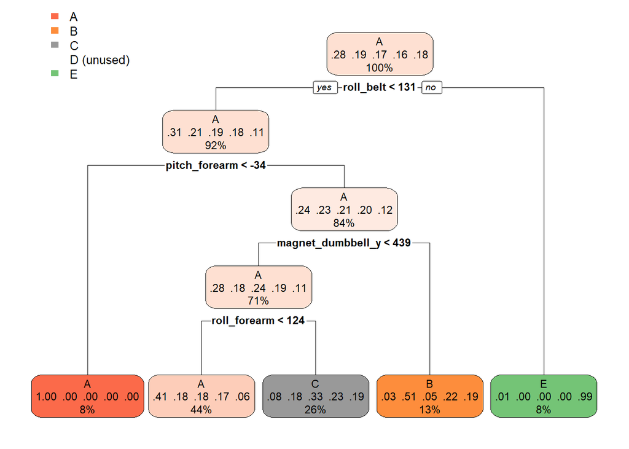

```r
rpart.plot(dt.modifit$finalModel, )
```

### Random forest model

```r
# fit model
RF.modfit <- train(classe ~ ., data =training.2, method = "rf", ntree = 128)
# prediction
RF.prediction <- predict(RF.modfit, cross.val)

RF.conf <- confusionMatrix(RF.prediction, as.factor(cross.val$classe))
RF.conf
```

```
## Confusion Matrix and Statistics
##
##           Reference
## Prediction    A    B    C    D    E
##          A 1394    7    0    0    0
##          B    0  937    1    0    0
##          C    1    4  851    7    0
##          D    0    1    3  797    2
##          E    0    0    0    0  899
##
## Overall Statistics
##
##                Accuracy : 0.9947
##                  95% CI : (0.9922, 0.9965)
##     No Information Rate : 0.2845
##     P-Value [Acc > NIR] : < 2.2e-16
##
##                   Kappa : 0.9933
##
##  Mcnemar's Test P-Value : NA
##
## Statistics by Class:
##
##                      Class: A Class: B Class: C Class: D Class: E
## Sensitivity            0.9993   0.9874   0.9953   0.9913   0.9978
## Specificity            0.9980   0.9997   0.9970   0.9985   1.0000
## Pos Pred Value         0.9950   0.9989   0.9861   0.9925   1.0000
## Neg Pred Value         0.9997   0.9970   0.9990   0.9983   0.9995
## Prevalence             0.2845   0.1935   0.1743   0.1639   0.1837
## Detection Rate         0.2843   0.1911   0.1735   0.1625   0.1833
## Detection Prevalence   0.2857   0.1913   0.1760   0.1637   0.1833
## Balanced Accuracy      0.9986   0.9936   0.9962   0.9949   0.9989
```

Plot the accuracy level

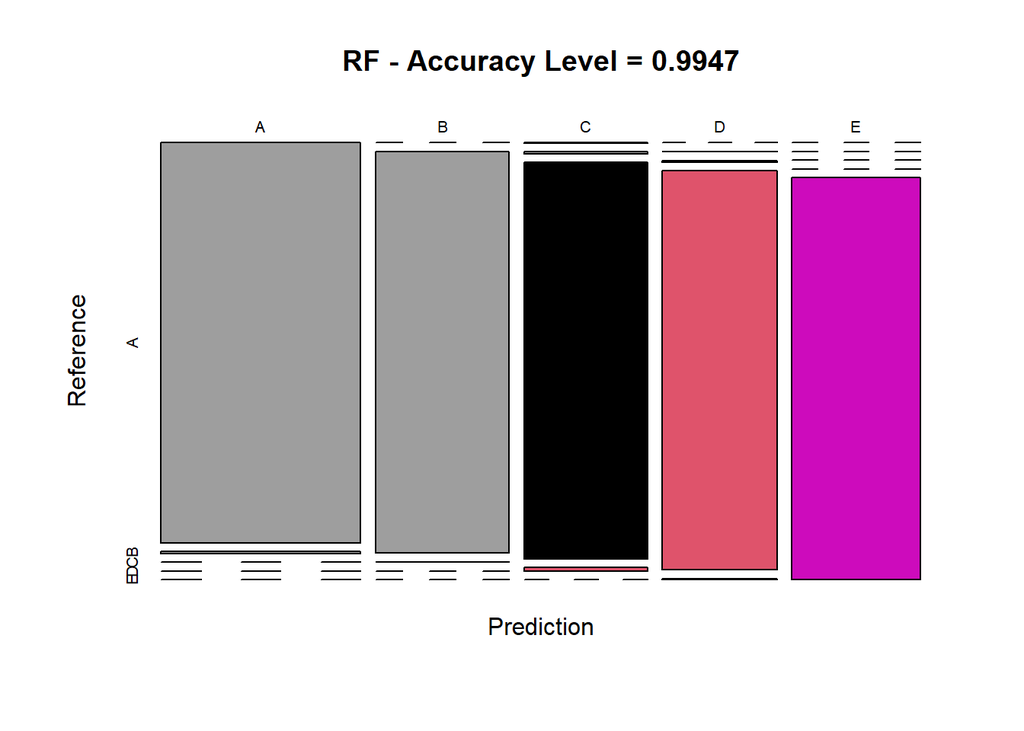

```r
plot(RF.conf$table, col = as.factor(RF.conf$byClass),
     main = paste("RF - Accuracy Level =",
                  round(RF.conf$overall['Accuracy'], 4)))
```

### Test set

```r
predict(RF.modfit, base.testing)
```

```
##  [1] B A B A A E D B A A B C B A E E A B B B
## Levels: A B C D E
```

## Conclusion

Base on the confusion matrices,the Random forest algorithm has the best performance and accuracy compared to the Decision Trees, that is why this algorithm is selected.